STAT 432 • Week 11

# Homework 11 — Worked Solutions

K-means implementation · Image color compression · Hierarchical clustering

Computed using NumPy, Pandas, SciPy, Matplotlib and Pillow. All figures are embedded; this HTML works offline.

## Question 1 — Implementing K-means

I generated 10 two-dimensional observations from independent standard normal distributions using **seed 43211** (`np.random.default_rng(43211).standard_normal((10, 2))`). I used K = 2 and randomly initialized both clusters with at least one observation.

### (a) One K-means iteration

Starting assignments (clusters numbered 1 and 2): `2, 2, 2, 1, 1, 1, 1, 2, 1, 2`. The means computed from these initial groups are **m₁ = [-0.069, -0.178]** and **m₂ = [0.044, 0.309]**. Assigning each observation to the nearest mean by Euclidean distance gives:

| Observation | x₁ | x₂ | Initial cluster | Updated cluster |
| --- | --- | --- | --- | --- |
| 1 | 0.428 | -0.604 | 2 | 1 |
| 2 | 0.493 | 0.990 | 2 | 2 |
| 3 | 1.074 | -0.960 | 2 | 1 |
| 4 | -0.987 | -0.923 | 1 | 1 |
| 5 | -0.831 | 1.181 | 1 | 2 |
| 6 | 1.510 | 0.195 | 1 | 2 |
| 7 | -0.655 | -0.834 | 1 | 1 |
| 8 | -0.926 | 1.399 | 2 | 2 |
| 9 | 0.618 | -0.511 | 1 | 1 |
| 10 | -0.846 | 0.720 | 2 | 2 |

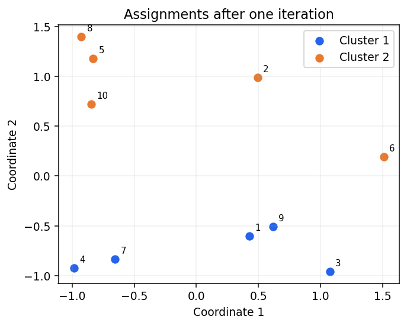

### (b) General K-means function

The function below accepts an *n × p* data matrix, any valid K, initial nonempty cluster assignments, and a maximum iteration count. At each iteration it recomputes the means and assigns observations to the nearest mean. Empty clusters retain their previous center for the next assignment step. The returned means are recomputed from the final assignments, and the objective is the within-cluster sum of squared Euclidean distances (WCSS).

```
import numpy as np

def cluster_means(X, labels, K, previous=None):
    centers = np.empty((K, X.shape[1]))
    for k in range(K):
        if np.any(labels == k):
            centers[k] = X[labels == k].mean(axis=0)
        else:
            centers[k] = previous[k] if previous is not None else X[k]
    return centers

def my_kmeans(X, K, initial_labels, max_iter=100):
    X = np.asarray(X, dtype=float)
    labels = np.asarray(initial_labels, dtype=int).copy()  # 0,...,K-1
    assert X.ndim == 2 and len(labels) == len(X)
    assert set(labels) == set(range(K))  # nonempty initial clusters
    for iteration in range(max_iter):
        centers = cluster_means(X, labels, K)
        distance_squared = ((X[:, None, :] - centers[None, :, :])**2).sum(axis=2)
        updated = np.argmin(distance_squared, axis=1)
        if np.array_equal(updated, labels):
            break
        labels = updated
    centers = cluster_means(X, labels, K, previous=centers)
    wcss = float(((X - centers[labels])**2).sum())
    return labels, centers, wcss
```

### (c) Two random initializations

**Run A** starts from `2, 2, 2, 1, 1, 1, 1, 2, 1, 2`; **Run B** starts from `2, 2, 1, 1, 2, 2, 1, 1, 2, 1`. Both use the same 10 observations.

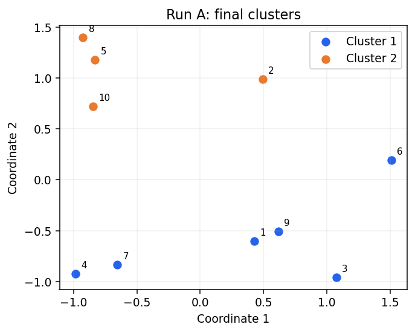

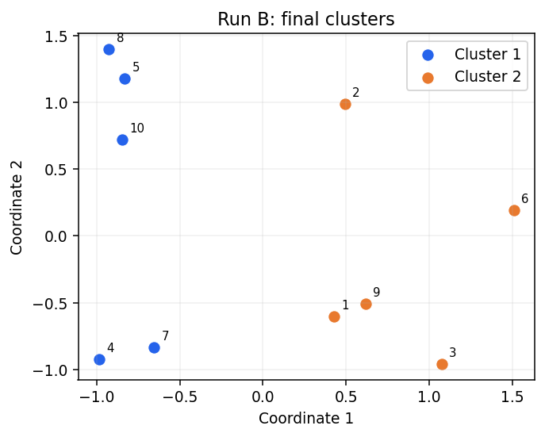

| Result | Run A | Run B |
| --- | --- | --- |
| Iterations | 3 | 2 |
| Final cluster 1 mean | [0.331, -0.606] | [-0.849, 0.309] |
| Final cluster 2 mean | [-0.528, 1.072] | [0.825, -0.178] |
| Within-cluster SS | 7.31668 | 8.25136 |
| Final assignments | 1, 2, 1, 1, 2, 1, 1, 2, 1, 2 | 2, 2, 2, 1, 1, 2, 1, 1, 2, 1 |

**Comparison:** The two runs reach different within-cluster sums of squares and different partitions. This demonstrates that K-means can converge to different local optima depending on the initial assignments. Run A has the smaller WCSS; checking all 511 ways to split the 10 points into two nonempty groups shows that Run A’s partition (WCSS 7.317) is the global minimum, while Run B stops at a local optimum (WCSS 8.251) and no further K-means iteration can improve it.

## Question 2 — Image color compression

### (a) Image and pixel data

I selected a small original illustrated landscape (sky, mountains, sun, trees and field), created directly for this assignment. Its dimensions are **120 × 90 pixels**, with three RGB channels. Reshaping it produces a matrix with **10,800 rows and 3 columns**. RGB values are on the common 0–255 scale.

### (b) K-means for K = 2, 3, 5 and 10

I applied the custom function from Question 1 to the 10,800 × 3 RGB matrix (0–255 scale). Because K-means only finds a local optimum, a single random start can land on a poor solution. For each K I therefore ran the function from **100 different nonempty initial assignments** (seed 20261108 + K; each start assigns pixels to the nearest of K randomly chosen, spread-out pixels) and kept the run with the *smallest* within-cluster sum of squares. Each compressed image replaces every pixel's RGB triplet with its cluster's mean RGB triplet, displayed on the same 0–255 scale.

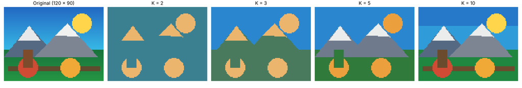

| K | Iterations (best run) | WCSS (RGB²) | WCSS per pixel |
| --- | --- | --- | --- |
| 2 | 1 | 70,544,374 | 6,531.9 |
| 3 | 1 | 38,112,546 | 3,528.9 |
| 5 | 1 | 12,933,104 | 1,197.5 |
| 10 | 2 | 1,034,452 | 95.8 |

Iterations count every pass of the loop, including the final pass that confirms the assignments no longer change. Random starts matter a lot: for K = 10, the 100 starts ranged from about 1.03 million to 4.04 million WCSS, and for K = 5 from 12.9 million to 27.1 million.

**RGB cluster means** (rounded to one decimal; clusters listed from darkest to brightest, numbering is arbitrary):

| K | Cluster | Red | Green | Blue |
| --- | --- | --- | --- | --- |
| 2 | 1 | 59.6 | 128.5 | 145.4 |
| 2 | 2 | 236.6 | 181.7 | 111.0 |
| 3 | 1 | 74.1 | 122.9 | 93.1 |
| 3 | 2 | 42.2 | 135.3 | 208.0 |
| 3 | 3 | 236.6 | 181.7 | 111.0 |
| 5 | 1 | 48.4 | 122.3 | 60.1 |
| 5 | 2 | 42.2 | 135.3 | 208.0 |
| 5 | 3 | 111.7 | 123.7 | 141.4 |
| 5 | 4 | 236.9 | 160.2 | 61.6 |
| 5 | 5 | 235.7 | 236.3 | 236.3 |
| 10 | 1 | 107.7 | 75.4 | 45.2 |
| 10 | 2 | 31.7 | 135.5 | 64.3 |
| 10 | 3 | 85.0 | 105.0 | 130.0 |
| 10 | 4 | 38.5 | 120.5 | 201.6 |
| 10 | 5 | 207.0 | 75.0 | 52.0 |
| 10 | 6 | 47.6 | 156.7 | 217.3 |
| 10 | 7 | 125.0 | 133.0 | 147.0 |
| 10 | 8 | 240.0 | 168.0 | 55.0 |
| 10 | 9 | 255.0 | 213.0 | 75.0 |
| 10 | 10 | 235.7 | 236.3 | 236.3 |

### (c) Preferred number of colors

I would choose **K = 10** for this image. The WCSS falls from about 70.5 million at K = 2 to 38.1 million at K = 3 and 12.9 million at K = 5, and then drops by a further factor of more than 12 to about 1.03 million at K = 10 (about 96 per pixel, i.e. a typical color error of roughly 10 RGB units). The reconstructions show why: K = 5 merges the red circle into the orange family, merges the two sky tones into one, folds the trunk and path into the green field, and loses the sun’s yellow, while K = 10 reproduces every distinct region of the picture (sun, snow caps, both mountains, red and orange circles, trunk and path, field and two sky tones). This image is made of roughly ten flat colors, so K = 10 gives a near-exact fit; for a photograph with a smooth range of colors the elbow would typically come earlier. Because K-means is run from random starts, the lowest-WCSS result over many starts should be used when comparing different K.

## Question 3 — Hierarchical clustering of cars

### (a) Standardization and three linkage methods

The provided `mtcars.csv` contains **32 cars and 11 numeric variables**. I excluded the `car` name column from the distance calculation and used it only for dendrogram labels. Each numeric variable was transformed using `(value − sample mean) / sample standard deviation`. I then computed Euclidean distances and fit single, complete and average linkage hierarchical clustering.

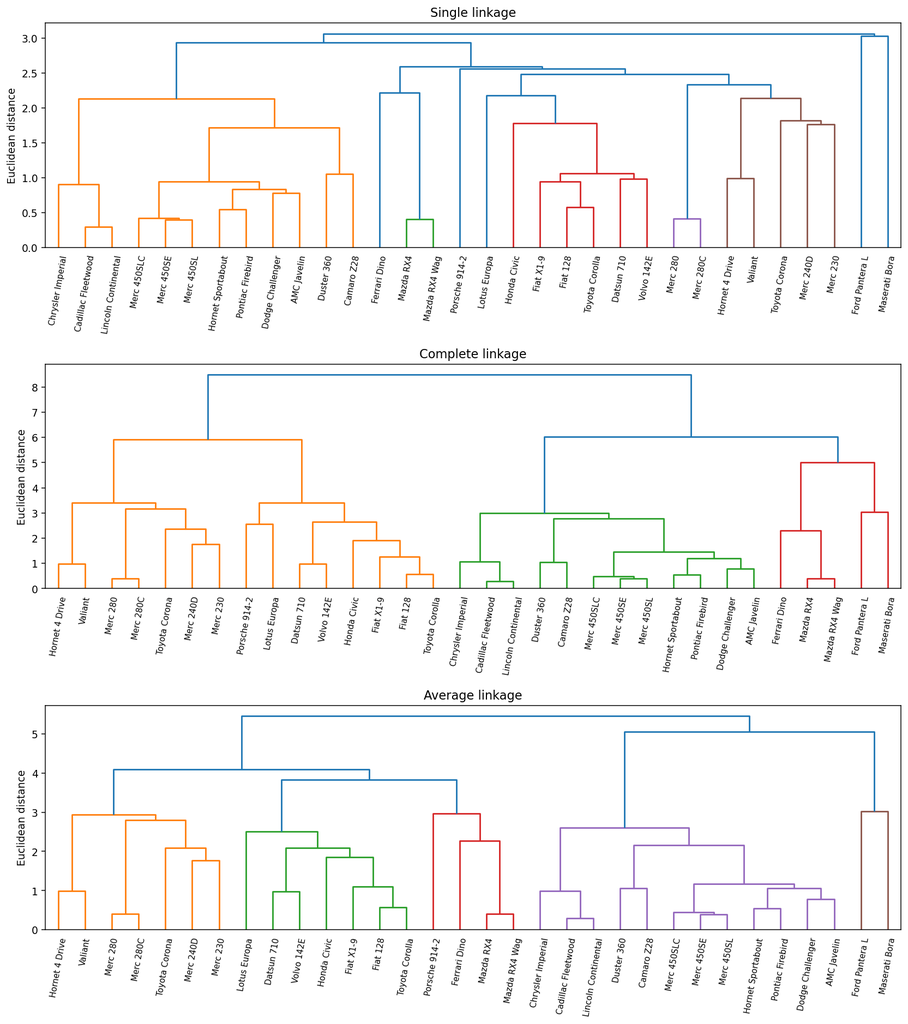

**Comparison:** Single linkage joins groups according to their nearest pair and can exhibit chaining, adding individual cars to a long cluster. Complete linkage uses the farthest pair, generally favoring tighter, more compact groups. Average linkage uses mean pairwise distances and often produces an intermediate compromise. The dendrogram branch heights show dissimilarities at which cars or groups merge, and their precise cluster compositions differ by linkage method.

### (b) Selected solution: complete linkage, 3 clusters

I chose **complete linkage with three clusters** to obtain a manageable, interpretable partition while limiting the chaining seen with single linkage. The three-group cut is an analytical choice rather than a uniquely correct number of clusters.

**Cluster memberships:**

| Cluster | Number of cars | Cars |
| --- | --- | --- |
| 1 | 15 | Datsun 710, Hornet 4 Drive, Valiant, Merc 240D, Merc 230, Merc 280, Merc 280C, Fiat 128, Honda Civic, Toyota Corolla, Toyota Corona, Fiat X1-9, Porsche 914-2, Lotus Europa, Volvo 142E |
| 2 | 12 | Hornet Sportabout, Duster 360, Merc 450SE, Merc 450SL, Merc 450SLC, Cadillac Fleetwood, Lincoln Continental, Chrysler Imperial, Dodge Challenger, AMC Javelin, Camaro Z28, Pontiac Firebird |
| 3 | 5 | Mazda RX4, Mazda RX4 Wag, Ford Pantera L, Ferrari Dino, Maserati Bora |

**Means on the original measurement scales:**

| Cluster | n | mpg | cyl | disp | hp | drat | wt | qsec | vs | am | gear | carb |
| --- | --- | --- | --- | --- | --- | --- | --- | --- | --- | --- | --- | --- |
| 1 | 15 | 24.65 | 4.53 | 131.65 | 91.33 | 3.90 | 2.58 | 19.16 | 0.93 | 0.53 | 3.93 | 1.80 |
| 2 | 12 | 15.05 | 8.00 | 357.62 | 194.17 | 3.12 | 4.10 | 17.14 | 0.00 | 0.00 | 3.00 | 3.08 |
| 3 | 5 | 18.50 | 6.80 | 223.40 | 198.80 | 3.84 | 3.00 | 15.62 | 0.00 | 1.00 | 4.60 | 5.20 |

**Why standardize?** Without scaling, variables with large numerical ranges (for example, horsepower or displacement) can dominate Euclidean distance, even when other variables are just as substantively important. Z-scoring places all 11 variables on comparable unit-variance scales so the clustering reflects their combined standardized differences.

## Reproducibility and notes

**Seeds:** Question 1 uses 43211; Question 2 uses 20261108 (plus K for each K, 100 starts per K). Question 3 is deterministic given the data and linkage method. Cluster numbering is arbitrary and does not represent an ordering of quality.

**Implementation:** Questions 1 and 2 use the handwritten K-means function above, not a library K-means estimator. Question 3 uses `scipy.cluster.hierarchy.linkage` and `fcluster`. WCSS is computed as the sum of squared differences between every observation and its assigned center.

**Submission note:** This report includes complete worked answers, computed tables and figures. Question 2 was recomputed with 100 random starts per K because the earlier single-start fits were poor local optima (e.g. K = 10 had WCSS 18.4 million instead of 1.03 million, K = 5 had 22.9 million instead of 12.9 million). Review the wording and results before submitting, and follow any course-specific academic-integrity or formatting requirements.